# meth05_regional_analysis

Epigenetics Bootcamp Summer 2024

# Regional DNA methylation analysis using DMRcate

Using data preprocessed in our script: meth01_process_data.R

```r
options(warn=-1)
suppressMessages(library(data.table))
suppressMessages(library(stringi))
suppressMessages(library(limma))
suppressMessages(library(minfi))
suppressMessages(library(missMethyl))
suppressMessages(library(ChAMP))
options(warn=0)
```

load the data

```r
load("data/processed.rda")

betas.clean <- beta[manifest[manifest$probe_type=="cg" & !chr %in% c("X","Y")]$index,]
```

# Introduction to differential variability analysis

See [Phipson and Oshlack. Genome Biol 2014](https://pubmed.ncbi.nlm.nih.gov/25245051/).

Impute missing Beta-values (varFit will produce an error with missingness)

```r
sum(is.na(betas.clean))
```

```
## [1] 492761
```

The champ.impute function prints a lot of information when running, so we’ll use this function to suppress the progress messages

```r
hush=function(code){
  sink("NUL") # use /dev/null in UNIX
  tmp = code
  sink()
  return(tmp)
}

betas.impute <- hush(champ.impute(beta=betas.clean, pd=pheno, k=5,
                                  ProbeCutoff=0.2, SampleCutoff=0.1))
betas.impute <- betas.impute$beta
```

coef parameter in varFit states which columns of design matrix correspond to the intercept and variable of interest  
If Beta-values are used, a lofit transformation is performed within the varFit function

```r
model <- model.matrix( ~smoker+sex+CD4+CD8+NK+B+MO,data=pheno)
head(model)
```

```
##   (Intercept) smokersmoker sexm        CD4          CD8         NK          B
## 1           1            0    0 0.10761054 5.901761e-02 0.08472436 0.03962468
## 2           1            0    1 0.12337854 1.318642e-03 0.04728698 0.06016857
## 3           1            0    0 0.03090017 8.673617e-19 0.03726568 0.03448483
## 4           1            0    1 0.05289147 1.450609e-02 0.03718517 0.04297929
## 5           1            0    0 0.10855311 1.092067e-01 0.08744554 0.06901653
## 6           1            0    0 0.11014519 1.642375e-01 0.03866907 0.06305253
##           MO
## 1 0.08171631
## 2 0.05527044
## 3 0.07121481
## 4 0.09250763
## 5 0.05354653
## 6 0.07237162
```

```r
EWAS.diffVar <- varFit(betas.impute, design=model, coef=c(1,2))
Top.diffVar <- topVar(EWAS.diffVar, coef=2, number=10, sort =TRUE)
Top.diffVar
```

```
##            SampleVar LogVarRatio DiffLevene         t      P.Value  Adj.P.Value
## cg01208126 0.4532781   -4.099035 -0.9831364 -6.998463 9.781137e-10 0.0007986141
## cg10954330 0.3166683   -3.254875 -0.7638673 -6.280935 2.066346e-08 0.0084356928
## cg07283849 0.3681882   -3.261963 -0.8125862 -6.149642 4.418440e-08 0.0120252864
## cg11010744 1.0616249   -4.963509 -1.2179124 -5.970938 7.523913e-08 0.0144658949
## cg06744150 0.5581872    4.583075  0.8969980  5.927031 9.021191e-08 0.0144658949
## cg15170234 0.4319618   -3.536224 -0.8354151 -5.887235 1.063038e-07 0.0144658949
## cg03297418 0.6344533   -3.779637 -0.9659578 -5.788697 1.593671e-07 0.0185886685
## cg08493522 0.3598942   -3.277723 -0.7484259 -5.642781 2.890636e-07 0.0260713659
## cg15765638 0.8244979   -3.820648 -0.9786104 -5.622900 3.133656e-07 0.0260713659
## cg11418915 0.4993287   -4.033311 -0.8573974 -5.578889 3.745490e-07 0.0260713659
```

Bind results with annotation

```r
Annot <- as.data.frame(getAnnotation(IlluminaHumanMethylationEPICanno.ilm10b4.hg19))
Annot.Top.diffVar <- Annot[match(rownames(Top.diffVar),Annot$Name),]
Annot.Top.diffVar <- Annot.Top.diffVar[,c("UCSC_RefGene_Name","UCSC_RefGene_Group","Relation_to_Island","chr","pos")]
Top.diffVar <- cbind(Top.diffVar, Annot.Top.diffVar)
```

Order by chr and chromosomal position

```r
Top.diffVar$chr <- as.numeric(gsub("chr", "", Top.diffVar$chr))
Top.diffVar[,c(2,6)] <- round(Top.diffVar[,c(2,6)],2)
Top.diffVar[order(Top.diffVar$chr, Top.diffVar$pos),c(2,5,6,7,10,11)]
```

```
##            LogVarRatio      P.Value Adj.P.Value UCSC_RefGene_Name chr       pos
## cg01208126       -4.10 9.781137e-10        0.00 FLJ44606;FLJ44606   5 126409573
## cg11010744       -4.96 7.523913e-08        0.01                     7    171613
## cg07283849       -3.26 4.418440e-08        0.01                     7  97401062
## cg15765638       -3.82 3.133656e-07        0.03                     7 152600816
## cg10954330       -3.25 2.066346e-08        0.01          PPAPDC1A  10 122262397
## cg11418915       -4.03 3.745490e-07        0.03                    11  56766325
## cg06744150        4.58 9.021191e-08        0.01       FARP1;FARP1  13  99069161
## cg08493522       -3.28 2.890636e-07        0.03                    17  14672369
## cg15170234       -3.54 1.063038e-07        0.01              CCL8  17  32645128
## cg03297418       -3.78 1.593671e-07        0.02                    20    937221
```

We can see differences in variability among the top sites

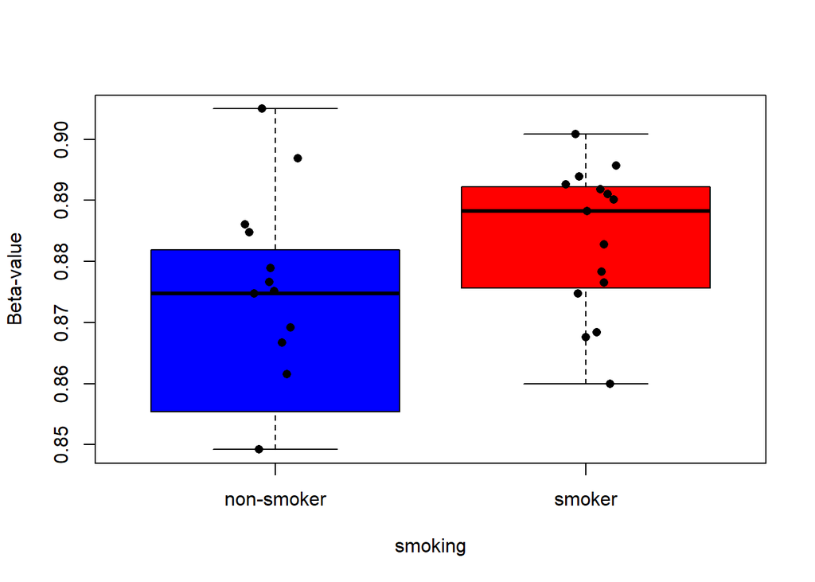

```r
cpg1 <- data.frame(id = colnames(betas.impute),
                   beta = betas.impute[rownames(betas.impute) == 'cg01208126',])
cpg1 <- merge(cpg1, pheno[,c('gsm', 'smoker')], by.x = 'id', by.y = 'gsm')
cpg1$smoker <- as.numeric(factor(cpg1$smoker))

cpg2 <- data.frame(id = colnames(betas.impute),
                   beta = betas.impute[rownames(betas.impute) == 'cg10954330',])
cpg2 <- merge(cpg2, pheno[,c('gsm', 'smoker')], by.x = 'id', by.y = 'gsm')
cpg2$smoker <- as.numeric(factor(cpg2$smoker))

boxplot(cpg1$beta ~ cpg1$smoker, col = c("blue", "red"), outline = F,
        xlab = 'smoking', ylab = 'Beta-value',
        names = c("non-smoker", "smoker"));points(jitter(cpg1$smoker, amount = 0.1),
                                                  cpg1$beta, pch = 16)
```

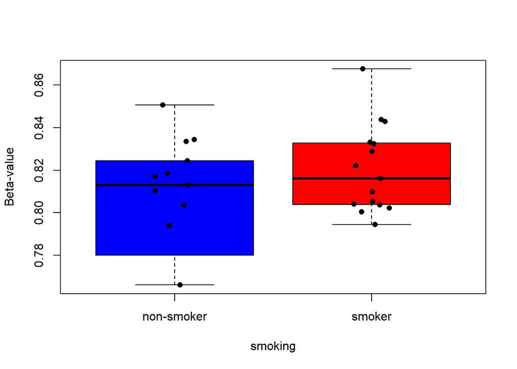

```r
boxplot(cpg2$beta ~ cpg2$smoker, col = c("blue", "red"), outline = F,
        xlab = 'smoking', ylab = 'Beta-value',
        names = c("non-smoker", "smoker"));points(jitter(cpg1$smoker, amount = 0.1),
                                                  cpg2$beta, pch = 16)
```

Note that diffVar results may be influenced by outliers, and therefore it is helpful to visually inspect results.

```r
rm(Annot.Top.diffVar,Top.diffVar,EWAS.diffVar,betas.impute,cpg1,cpg2);gc()
```

```
##             used   (Mb) gc trigger   (Mb)  max used   (Mb)
## Ncells  22157724 1183.4   40282688 2151.4  40282688 2151.4
## Vcells 282824026 2157.8  764797924 5835.0 764797924 5835.0
```

# Introduction to regional analyses with DMRcate

```r
suppressMessages(library(DMRcate)) # Popular package for regional DNA methylation analysis
```

Regions are now agglomerated from groups of significant probes  
Let’s run the regional analysis using the Beta-values from our preprocessed data

```r
myannotation <- cpg.annotate("array", na.omit(betas.clean),
                             analysis.type="differential",arraytype="EPIC",
                             what="Beta",design=model, coef=2)
```

```
## Your contrast returned 46 individually significant probes; a small but real effect. Consider manually setting the value of pcutoff to return more DMRs, but be warned that doing this increases the risk of Type I errors.
```

```r
# set analysis.type = "diffVar" to return differentially variable methylated regions
```

Regions are now agglomerated from groups of significant probes where the distance to the next consecutive probe is less than lambda nucleotides away

```r
dmrcoutput.smoking <- dmrcate(myannotation, lambda=1000, C=2)
```

[output not shown]

[output not shown]

[output not shown]

[output not shown]

[output not shown]

[output not shown]

[output not shown]

[output not shown]

[output not shown]

[output not shown]

[output not shown]

[output not shown]

[output not shown]

[output not shown]

[output not shown]

[output not shown]

[output not shown]

[output not shown]

[output not shown]

[output not shown]

[output not shown]

[output not shown]

```
## Demarcating regions...
```

```
## Done!
```

Let’s look at the results

```r
results.ranges <- extractRanges(dmrcoutput.smoking, genome = "hg19")
```

```
## snapshotDate(): 2022-10-31
```

```
## see ?DMRcatedata and browseVignettes('DMRcatedata') for documentation
```

```
## loading from cache
```

```r
head(results.ranges)
```

```
## GRanges object with 6 ranges and 8 metadata columns:
##       seqnames              ranges strand |   no.cpgs min_smoothed_fdr
##          <Rle>           <IRanges>  <Rle> | <integer>        <numeric>
##   [1]     chr5       373299-374093      * |         4     2.65192e-122
##   [2]     chr2 233284112-233285454      * |         5      2.91461e-79
##   [3]     chr1   92946132-92947588      * |         7      3.85085e-58
##   [4]    chr14 106329206-106330538      * |        10      5.10670e-51
##   [5]     chr2   27665079-27665711      * |         9      6.66048e-47
##   [6]     chr3   21792248-21793157      * |        10      1.36879e-47
##          Stouffer       HMFDR      Fisher   maxdiff   meandiff
##         <numeric>   <numeric>   <numeric> <numeric>  <numeric>
##   [1] 5.42369e-01 2.66747e-11 6.55447e-10 -0.390113 -0.1669167
##   [2] 1.12189e-02 3.61746e-06 9.34190e-09 -0.257728 -0.1075363
##   [3] 9.90825e-10 1.66572e-03 1.28665e-08 -0.257684 -0.1726661
##   [4] 2.56008e-04 7.23322e-02 1.76917e-03 -0.141353 -0.1070767
##   [5] 3.65814e-03 9.48767e-02 1.63559e-02  0.317482  0.1964887
##   [6] 1.19876e-01 7.39242e-02 1.93909e-02 -0.157450 -0.0754356
##            overlapping.genes
##                  <character>
##   [1]                   AHRR
##   [2] AC068134.5, AC068134.6
##   [3]                   GFI1
##   [4] IGHJ6, IGHJ3P, IGHJ5..
##   [5]         NRBP1, KRTCAP3
##   [6]                ZNF385D
##   -------
##   seqinfo: 5 sequences from an unspecified genome; no seqlengths
```

Plot the DMR using the Gviz  
If you are interested in plotting genomic data the Gviz is extremely useful

Let’s look at the second region

```r
results.ranges[2]
```

```
## GRanges object with 1 range and 8 metadata columns:
##       seqnames              ranges strand |   no.cpgs min_smoothed_fdr
##          <Rle>           <IRanges>  <Rle> | <integer>        <numeric>
##   [1]     chr2 233284112-233285454      * |         5      2.91461e-79
##        Stouffer       HMFDR     Fisher   maxdiff  meandiff
##       <numeric>   <numeric>  <numeric> <numeric> <numeric>
##   [1] 0.0112189 3.61746e-06 9.3419e-09 -0.257728 -0.107536
##            overlapping.genes
##                  <character>
##   [1] AC068134.5, AC068134.6
##   -------
##   seqinfo: 5 sequences from an unspecified genome; no seqlengths
```

set up the grouping variables and colours

```r
pheno$smoker<-as.factor(pheno$smoker)
cols = c("magenta","red")[pheno$smoker]
names(cols) = levels(pheno$smoker)[pheno$smoker]
```

Draw the plot a DMR

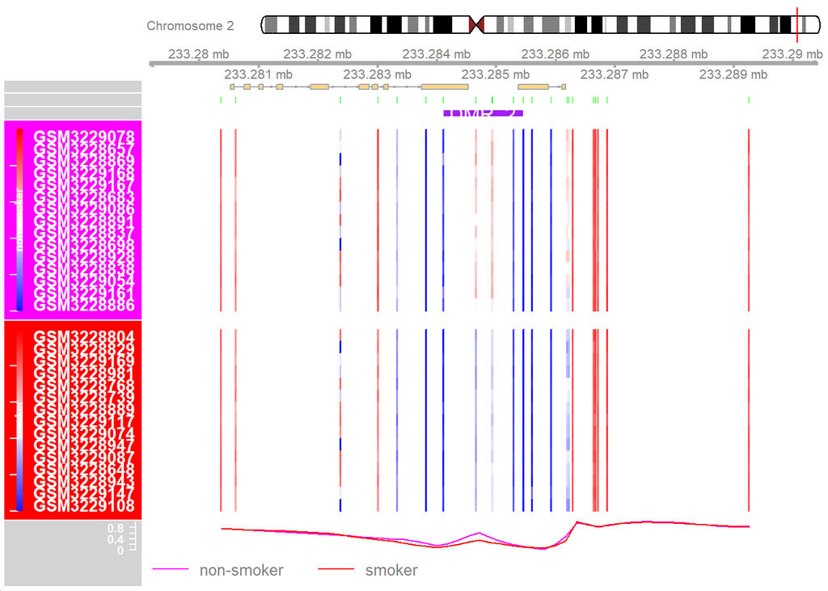

```r
DMR.plot(ranges=results.ranges, dmr=2, CpGs=betas.clean, phen.col=cols, what = "Beta",
         arraytype = "EPIC", pch=16, toscale=TRUE, plotmedians=TRUE,
         genome="hg19", samps=1:nrow(pheno))
```

Looking at another DMR

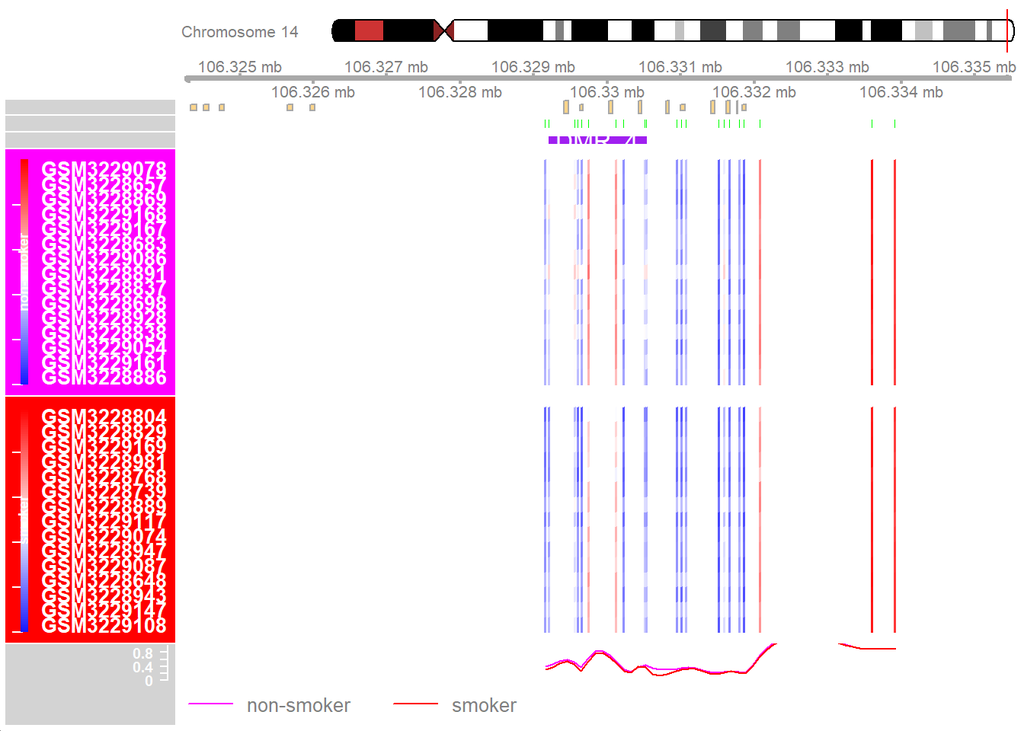

```r
DMR.plot(ranges=results.ranges, dmr=4, CpGs=betas.clean, phen.col=cols, what = "Beta",
         arraytype = "EPIC", pch=16, toscale=TRUE, plotmedians=TRUE,
         genome="hg19", samps=1:nrow(pheno))
```

Clean data

```r
rm(dmrcoutput.smoking,myannotation);gc()
```

```
##             used   (Mb) gc trigger   (Mb)  max used   (Mb)
## Ncells  22453136 1199.2   40282688 2151.4  40282688 2151.4
## Vcells 290940317 2219.7  764797924 5835.0 764797924 5835.0
```

# Introduction to regional analyses with comb-p

See [Pedersen et al. Bioinformatics 2012](https://academic.oup.com/bioinformatics/article/28/22/2986/240603).

```r
suppressMessages(library(ENmix))
```

Input is a data frame with colnames “chr”, “start”, “end”, “p” and “probe”  
Using p-values from limma

```r
EWAS.limma <- eBayes(lmFit(betas.clean, design=model))
EWAS.limma <- topTable(EWAS.limma, coef=2, number=Inf, sort.by="p")
EWAS.limma <- EWAS.limma[!is.na(EWAS.limma$logFC),]
```

Add chr and pos

```r
EWAS.limma <- cbind(EWAS.limma, chr = Annot[,"chr"][match(rownames(EWAS.limma),
                                                          rownames(Annot))])
EWAS.limma <- cbind(EWAS.limma, pos = Annot[,"pos"][match(rownames(EWAS.limma),
                                                          rownames(Annot))])
EWAS.limma$end <- EWAS.limma$pos
```

keep only needed columns

```r
EWAS.combp <- EWAS.limma[,c("chr", "pos", "end", "P.Value")]
colnames(EWAS.combp) <- c("chr", "start", "end", "p")
EWAS.combp$probe = rownames(EWAS.combp)
EWAS.limma$chr <- as.numeric(gsub("chr", "", EWAS.limma$chr)) # chr as numeric
```

Run combp. Results saved in working directory.  
For efficiency, we’ll use output already generated.

```r
#combp(EWAS.combp, region_plot = F, mht_plot = F, dist.cutoff=1000, seed=0.001, verbose = T)

# parameters
### dist.cutoff = maximum distrance between basepairs to combine adjacent DMRs;
### seed = FDR significance threshold for initial selection of DMRs
```

read output

```r
combp.result = read.csv('combp/resu_combp.csv')
head(combp.result)
```

```
##     chr     start       end            p          fdr        sidak nprobe
## 1 chr14 106329157 106331073 2.659432e-36 1.037178e-34 0.000000e+00     14
## 2  chr1  92946131  92947588 2.838623e-23 5.535315e-22 0.000000e+00      7
## 3  chr2 233284660 233284934 1.116779e-18 1.451813e-17 0.000000e+00      2
## 4  chr2  27664917  27665711 7.250879e-18 7.069607e-17 0.000000e+00     10
## 5  chr5    373298    373378 3.155609e-17 2.461375e-16 0.000000e+00      2
## 6  chr3  21792433  21793157 2.973445e-15 1.932739e-14 3.481215e-12      9
##                                                                                                                                                       probe
## 1 cg13074055;cg08493167;cg10258214;cg01208318;cg07667906;cg23594345;cg15310518;cg27271698;cg01513913;cg09303399;cg12734136;cg03686998;cg12615852;cg15635485
## 2                                                                              cg09935388;cg12876356;cg18146737;cg09662411;cg06338710;cg04535902;cg18316974
## 3                                                                                                                                     cg21566642;cg01940273
## 4                                             cg17158414;cg20102877;cg12648201;cg12000995;cg11618577;cg21248554;cg24768116;cg26034919;cg04845466;cg26350635
## 5                                                                                                                                     cg05575921;cg23576855
## 6                                                        cg26077378;cg15160624;cg18503679;cg00485194;cg00687135;cg08023500;cg14550518;cg21436456;cg18267381
```

Other popular options for conducting Regional DNA methylation analysis in R are Aclust and bumphunter

Visualizing DMPs and DMRs using EWASplot

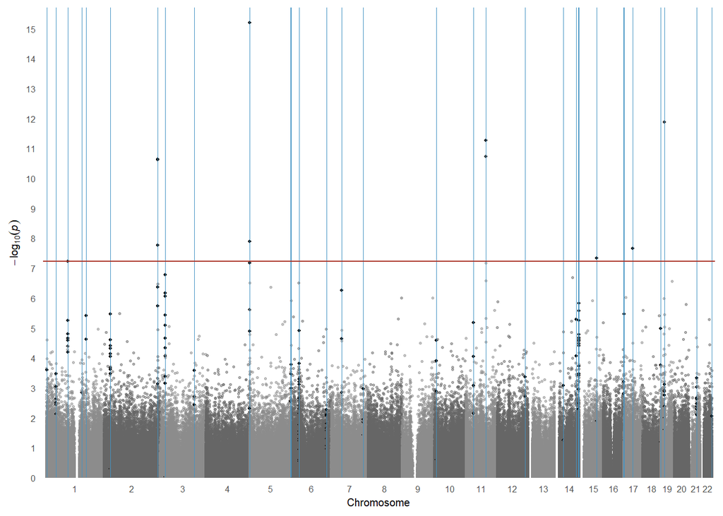

```r
suppressMessages(library(ggplot2))
suppressMessages(library(EWASplot))
manhattan_plot(probe = EWAS.limma, region = combp.result)
```

# Introduction to pathway analysis with gometh

see [Geeleher et al. Bioinformatics 2013](https://academic.oup.com/bioinformatics/article/29/15/1851/265573?login=false).

```r
keggResult = gometh(sig.cpg = rownames(EWAS.limma)[EWAS.limma$adj.P.Val < 0.05],
                    all.cpg = rownames(EWAS.limma), collection = 'KEGG')
```

```
## All input CpGs are used for testing.
```

```r
keggResult = keggResult[order(keggResult$P.DE),]
head(keggResult)
```

```
##                                          Description   N DE       P.DE FDR
## hsa04610         Complement and coagulation cascades  83  1 0.03385118   1
## hsa04611                         Platelet activation 123  1 0.07498929   1
## hsa04141 Protein processing in endoplasmic reticulum 162  1 0.08813897   1
## hsa05130       Pathogenic Escherichia coli infection 188  1 0.10865826   1
## hsa04814                              Motor proteins 190  1 0.11500078   1
## hsa04015                      Rap1 signaling pathway 207  1 0.13561573   1
```

Clean data

```r
rm(combp.result, EWAS.limma, EWAS.combp);gc()
```

```
##             used   (Mb) gc trigger   (Mb)  max used   (Mb)
## Ncells  22735044 1214.2   40282689 2151.4  40282689 2151.4
## Vcells 315205516 2404.9  764797924 5835.0 764797924 5835.0
```

# Predicting smoking with EpiSmokEr

see [Bollepalli, Sailalitha, et al. Epigenomics 2019](https://pubmed.ncbi.nlm.nih.gov/31466478/).

```r
suppressMessages(require(EpiSmokEr))
# Make sure rows of pheno match betas column names
rownames(pheno)<-pheno$gsm
identical(colnames(betas.clean),rownames(pheno))
```

```
## [1] TRUE
```

pheno needs a column for sex,in the format of 1 and 2 representing men and women respectively

```r
pheno$sex<-ifelse(pheno$sex=="m",1,2)
```

121 CpGs are used selected by LASSO along with Sex to get 3 categories (current, former and never smokers)

```r
result <- epismoker(dataset=betas.clean, samplesheet = pheno, method = "SSt")
```

```
## <<<<< Predicting Smoking Statuses >>>>>
```

```
## Replacing samples with NAs in methylation data with 0.5.
```

```
## Dataset has 111 of 121 CpGs required for smoking status estimation.
```

```
## Replacing samples with NAs in methylation data with 0.5.
```

```
## Dataset has 111 of 121 CpGs required for smoking status estimation.
```

```
## Replacing samples with NAs in methylation data with 0.5.
```

```
## Dataset has 111 of 121 CpGs required for smoking status estimation.
```

```
## <<<<< Prediction of Smoking Statuses Completed >>>>>
```

Let’s look how well the prediction performed

```r
table(pheno$smoker,result$PredictedSmokingStatus)
```

```
##
##              Current Smoker Former Smoker Never Smoker
##   non-smoker              0             4           11
##   smoker                 15             0            0
```

```r
rm(list = ls());gc()
```

```
##             used   (Mb) gc trigger   (Mb)  max used   (Mb)
## Ncells  22737744 1214.4   40282689 2151.4  40282689 2151.4
## Vcells 252263891 1924.7  764797924 5835.0 764797924 5835.0
```

End of script 05